# Regression Fundamentals

Applied Machine Learning in Economics

To prepare for next lecture, read:

- Chapter 4.1
- Chapter 4.2
- Chapter 4.3

For more practice, do:

- Lab 3.6

**Overview**

Today we are going to do some

1. EDA
2. Model selection
3. Hypothesis Testing
4. Inference
5. Do some prediction
6. Establish selected model quality of fit

**Preliminaries**

You don’t need to use `data.table` to load in the data, but I always do out of a force of habit. We will, however, almost always be using some of the packages that are inside of `tidyverse`.

```r
library(tidyverse)
library(data.table)
```

Loading in the data:

```r
ahs = fread('C:/Users/johnj/Documents/Data/Applied ML ECON490/lecture data/lecture data continuous.csv')
```

The `fread()` function is designed specifically for larger files. Ours is relatively small. How small you might ask?

Let’s remember that object size goes from bytes, kilobyte, megabyte, gigabyte, petabyte, and terabyte in orders of 1024. There are sizes beyond terabytes.

So, how big is our data?

```r
object.size(ahs)/1024^2
```

```
## 1.7 bytes
```

Only 1.7 megabytes. Pretty small. `fread()` will really come in handy once we start dealing with things that are approaching the gigabyte size.

Anyway, let’s get on with it…

# 1 EDA

We will create some summary (haha, they sound the same…) statistics and some lovely plots. This is always good practice when you approach your data for the first time. It helps you understand what patterns lie within the data.

## 1.1 Summary Statistics

```r
summary(ahs)
```

```
##       id                 cbsa         cbsaname             value
##  Length:9537        Min.   :12060   Length:9537        Min.   :      1
##  Class :character   1st Qu.:16980   Class :character   1st Qu.: 150910
##  Mode  :character   Median :26420   Mode  :character   Median : 258676
##                     Mean   :28014                      Mean   : 350039
##                     3rd Qu.:37980                      3rd Qu.: 421231
##                     Max.   :47900                      Max.   :9999998
##       cost           npeople           hinc              beds
##  Min.   :     4   Min.   :1.000   Min.   :      4   Min.   :0.000
##  1st Qu.:   733   1st Qu.:1.000   1st Qu.:  38000   1st Qu.:3.000
##  Median :  1230   Median :2.000   Median :  75000   Median :3.000
##  Mean   :  1599   Mean   :1.897   Mean   : 107161   Mean   :3.097
##  3rd Qu.:  1995   3rd Qu.:2.000   3rd Qu.: 128000   3rd Qu.:4.000
##  Max.   :100756   Max.   :3.000   Max.   :5566500   Max.   :5.000
##      baths          eqvval           lotsize             yos
##  Min.   :0.00   Min.   :   1504   Min.   : 0.0000   Min.   : 0.00
##  1st Qu.:1.50   1st Qu.: 181108   1st Qu.: 0.0625   1st Qu.:13.00
##  Median :2.00   Median : 315103   Median : 0.1875   Median :16.00
##  Mean   :2.09   Mean   : 356158   Mean   : 0.6587   Mean   :15.16
##  3rd Qu.:2.50   3rd Qu.: 449176   3rd Qu.: 0.3125   3rd Qu.:18.00
##  Max.   :4.00   Max.   :4182543   Max.   :10.0000   Max.   :20.00
##     hoa            condo           garage            bld
##  Mode :logical   Mode :logical   Mode :logical   Length:9537
##  FALSE:5863      FALSE:8331      FALSE:2226      Class :character
##  TRUE :3674      TRUE :1206      TRUE :7311      Mode  :character
##
##
##
##      crime            math            hinf           houtf
##  Min.   :273.4   Min.   :35.44   Min.   :4.365   Min.   : 6.256
##  1st Qu.:332.9   1st Qu.:40.86   1st Qu.:4.836   1st Qu.: 7.181
##  Median :369.3   Median :55.00   Median :6.017   Median : 8.002
##  Mean   :412.4   Mean   :53.82   Mean   :6.419   Mean   : 8.699
##  3rd Qu.:488.0   3rd Qu.:58.77   3rd Qu.:7.791   3rd Qu.: 9.879
##  Max.   :593.1   Max.   :79.10   Max.   :9.602   Max.   :13.135
```

Well, that produces a lot. Nonetheless, it is still useful to look through. For example, it gives us an idea of the distribution of the variables or what type they are, such as the variable `value`.

Do you remember how to tell whether a variable is left or right skewed from the mean and median of variable? Take a moment to think about it.

```r
mean(ahs$value); median(ahs$value)
```

```
## [1] 350038.7
```

```
## [1] 258676
```

## 1.2 Some Pretty(ish) Plots

What were are doing right now is EDA for ourselves, not for presentation. Remember that for presentation you should properly label you axis and titles, use color if applicable, and set your font size large enough so the person in the back of the room can see it.

### 1.2.1 Single Variables

Let’s revisit the `ahs$value` distribution.

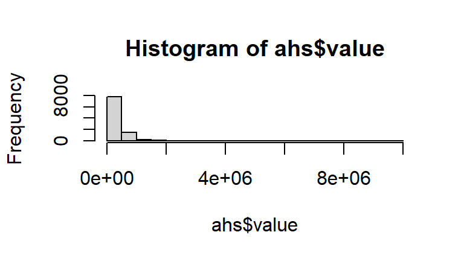

```r
hist(ahs$value)
```

WOW! That is mega right skewed. Whenever we see data like this, it is pretty likely that we will need to take a log transformation. We want to transform this variable to prevent bias in our estimates and reduce the variance in our predictions.

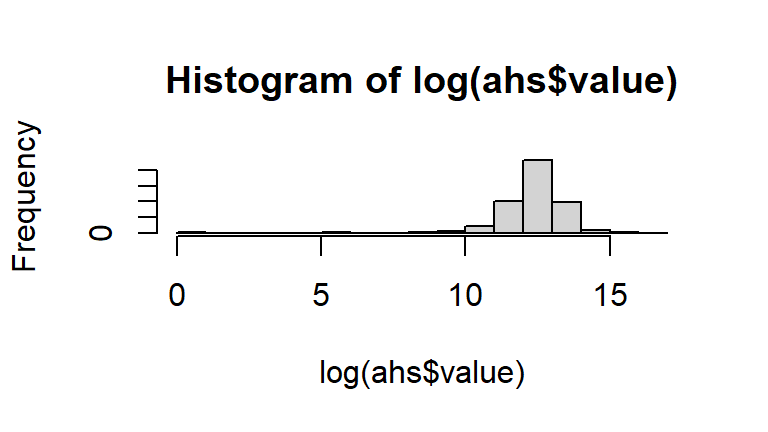

```r
hist(log(ahs$value))
```

Yup. That is looking much better! Notice how it looks normally distributed? This puts in the right direction of satisfying the regression assumption of normally distributed errors.

Typically when we are dealing with wage data, valuation data, or expenditures data, we need to take a log transformation. This is not a true blanket statement, so you should check:

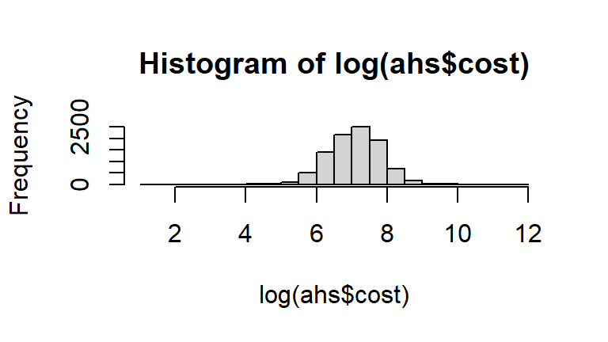

```r
hist(log(ahs$cost))
```

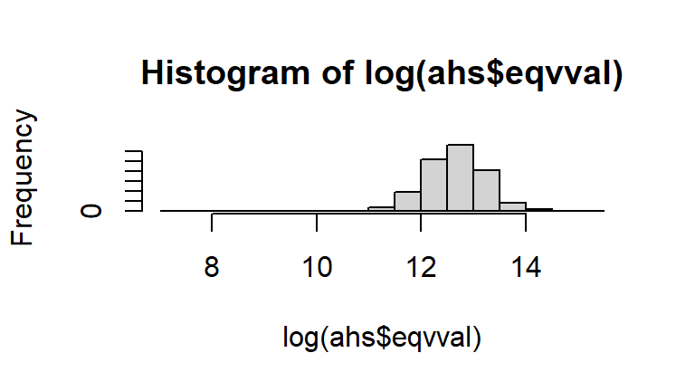

```r
hist(log(ahs$eqvval))
```

Both of those plots look like a log transformation is appropriate.

### 1.2.2 Multiple variables

There are various ways that we can plot different variables together. For example, if we have two continuous variables, we can

- make a small point scatter
- make a binned scatter
- make a 2d binned plot

For continuous versus discrete variables, we can use my favorite kind of plot, the violin plot.

And finally if we have two discrete variables, we can use a heatmap.

Here are some plots to guide our analysis

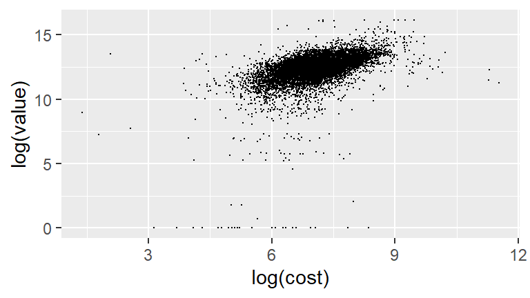

```r
ggplot(ahs, aes(y = log(value), x = log(cost))) +
  geom_point(size = 0.1)
```

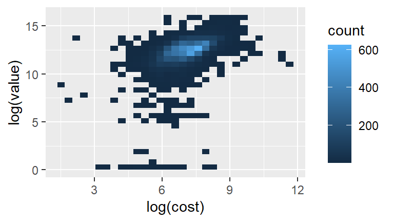

```r
ggplot(ahs, aes(y = log(value), x = log(cost))) +
  geom_bin2d()
```

[output not shown]

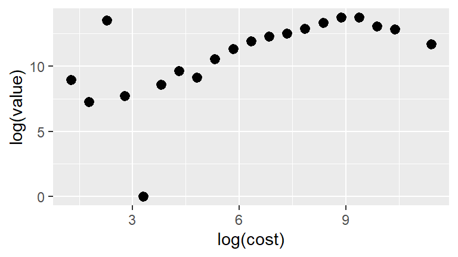

```r
ggplot(ahs, aes(y = log(value), x = log(cost))) +
  stat_summary_bin(bins = 20, fun = mean)
```

The binned scatter plot will warn you that observations have been removed if they do not fit equally into the number of bins.

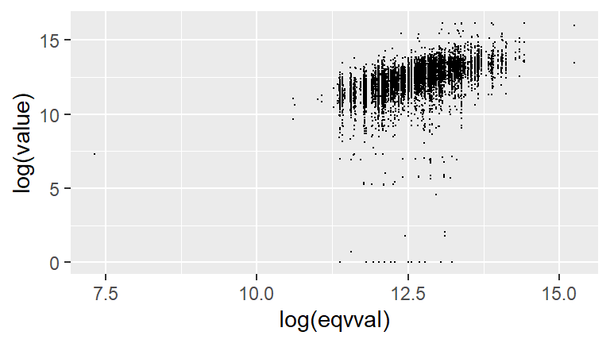

```r
ggplot(ahs, aes(y = log(value), x = log(eqvval))) +
  geom_point(size = 0.1)
```

**A question you should be able to answer**: Why does the plot produce the vertical columns?

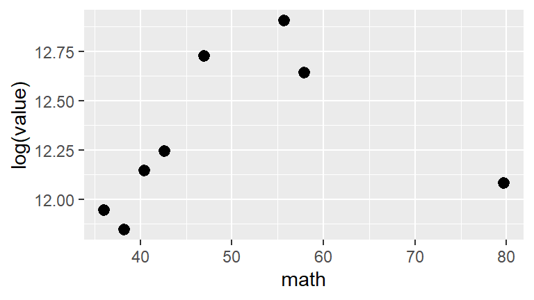

```r
ggplot(ahs, aes(y = log(value), x = math)) +
  stat_summary_bin(bins = 20, fun = mean)
```

Perhaps we will need a second order polynomial term.

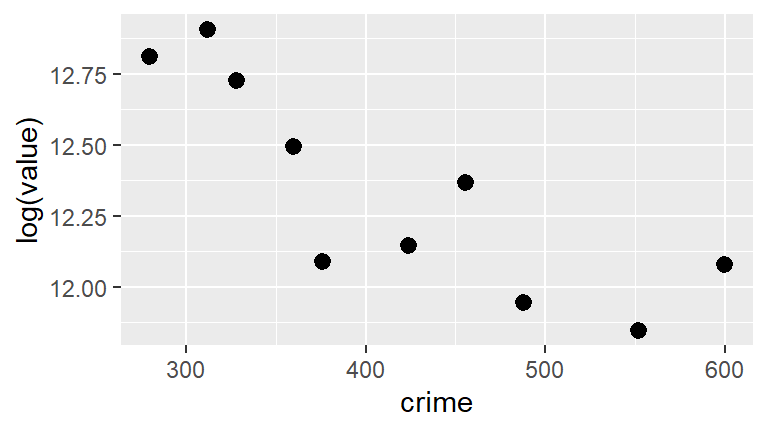

```r
ggplot(ahs, aes(y = log(value), x = crime)) +
  stat_summary_bin(bins = 20, fun = mean)
```

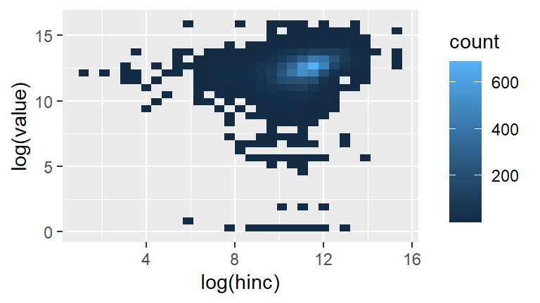

```r
ggplot(ahs, aes(y = log(value), x = log(hinc))) +
  geom_bin2d()
```

And now for the beautiful violin plots!

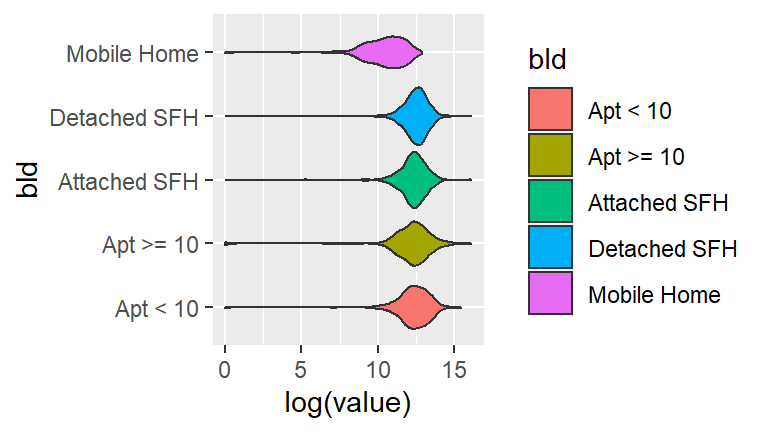

```r
ggplot(ahs, aes(x = log(value), y = bld, fill = bld)) +
  geom_violin()
```

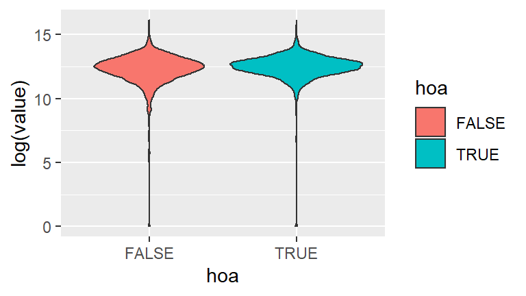

```r
ggplot(ahs, aes(y = log(value), x = hoa, fill = hoa)) +
  geom_violin()
```

Finally, the heatpmaps!

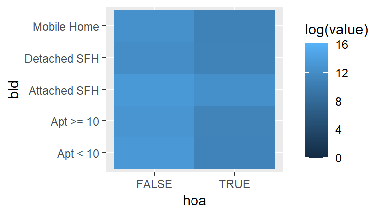

```r
ggplot(ahs, aes(x = hoa, y = bld, fill = log(value))) +
  geom_tile()
```

# 2 Model Selection

## 2.1 `lm()` Regression Overview

We are now going to run the first regression of the lecture series! We know from the plots above that `value` and `cost` appear to have a strong relationship. Let’s test that out!

```r
# lm stands for linear model
class(log(value) ~ log(cost))
```

```
## [1] "formula"
```

```r
lm(log(value) ~ log(cost), data = ahs)
```

```
##
## Call:
## lm(formula = log(value) ~ log(cost), data = ahs)
##
## Coefficients:
## (Intercept)    log(cost)
##      6.8955       0.7684
```

Great! But what if we want more information such as the significance levels? Then we use `summary`.

```r
fit = lm(log(value) ~ log(cost), ahs)
summary(fit)
```

```
##
## Call:
## lm(formula = log(value) ~ log(cost), data = ahs)
##
## Residuals:
##      Min       1Q   Median       3Q      Max
## -13.3136  -0.3516   0.0525   0.5125   5.0033
##
## Coefficients:
##             Estimate Std. Error t value Pr(>|t|)
## (Intercept)  6.89548    0.09867   69.89   <2e-16 ***
## log(cost)    0.76836    0.01384   55.50   <2e-16 ***
## ---
## Signif. codes:  0 '***' 0.001 '**' 0.01 '*' 0.05 '.' 0.1 ' ' 1
##
## Residual standard error: 1.017 on 9535 degrees of freedom
## Multiple R-squared:  0.2442, Adjusted R-squared:  0.2441
## F-statistic:  3081 on 1 and 9535 DF,  p-value: < 2.2e-16
```

Looks like we did a pretty good job!

If you recall from the EDA, it looks like the `math` variable was going to need a quadratic transformation. Let’s do it!

```r
lm(log(value) ~ poly(math, 2), ahs) %>% summary
```

```
##
## Call:
## lm(formula = log(value) ~ poly(math, 2), data = ahs)
##
## Residuals:
##      Min       1Q   Median       3Q      Max
## -12.7180  -0.3627   0.1304   0.5546   3.9321
##
## Coefficients:
##                 Estimate Std. Error  t value Pr(>|t|)
## (Intercept)     12.34115    0.01149 1073.915  < 2e-16 ***
## poly(math, 2)1   5.91353    1.12226    5.269  1.4e-07 ***
## poly(math, 2)2 -31.52607    1.12226  -28.092  < 2e-16 ***
## ---
## Signif. codes:  0 '***' 0.001 '**' 0.01 '*' 0.05 '.' 0.1 ' ' 1
##
## Residual standard error: 1.122 on 9534 degrees of freedom
## Multiple R-squared:  0.07892,    Adjusted R-squared:  0.07873
## F-statistic: 408.5 on 2 and 9534 DF,  p-value: < 2.2e-16
```

What if we only want to include the intercept and the second-degree term? Then we use the `I()` or interpret function.

```r
lm(log(value) ~ I(math^2), ahs) %>% summary
```

```
##
## Call:
## lm(formula = log(value) ~ I(math^2), data = ahs)
##
## Residuals:
##      Min       1Q   Median       3Q      Max
## -12.3432  -0.4173   0.1224   0.6122   3.7957
##
## Coefficients:
##              Estimate Std. Error t value Pr(>|t|)
## (Intercept) 1.230e+01  2.517e-02 488.694   <2e-16 ***
## I(math^2)   1.306e-05  7.133e-06   1.831   0.0671 .
## ---
## Signif. codes:  0 '***' 0.001 '**' 0.01 '*' 0.05 '.' 0.1 ' ' 1
##
## Residual standard error: 1.169 on 9535 degrees of freedom
## Multiple R-squared:  0.0003517,  Adjusted R-squared:  0.0002468
## F-statistic: 3.354 on 1 and 9535 DF,  p-value: 0.06706
```

Hmmm, that doesn’t look very good.

Notice that we can run this on a categorical variable.

```r
lm(log(value) ~ bld, ahs)
```

```
##
## Call:
## lm(formula = log(value) ~ bld, data = ahs)
##
## Coefficients:
##     (Intercept)     bldApt >= 10  bldAttached SFH  bldDetached SFH
##        12.26076         -0.06928          0.02556          0.17534
##  bldMobile Home
##        -1.84960
```

```r
# Versus
lm(log(value) ~ bld - 1, ahs)
```

```
##
## Call:
## lm(formula = log(value) ~ bld - 1, data = ahs)
##
## Coefficients:
##     bldApt < 10     bldApt >= 10  bldAttached SFH  bldDetached SFH
##           12.26            12.19            12.29            12.44
##  bldMobile Home
##           10.41
```

**Questions** What is the difference between these two models? How does the interpretation of the coefficients change?

What if we want an interaction term? Check out the differences between these two regressions.

```r
lm(log(value) ~ beds*baths, ahs) %>% summary
```

```
##
## Call:
## lm(formula = log(value) ~ beds * baths, data = ahs)
##
## Residuals:
##      Min       1Q   Median       3Q      Max
## -12.4902  -0.3655   0.0941   0.5359   4.3432
##
## Coefficients:
##             Estimate Std. Error t value Pr(>|t|)
## (Intercept) 11.36391    0.10374 109.541  < 2e-16 ***
## beds         0.01189    0.03374   0.352 0.724585
## baths        0.28914    0.05295   5.460 4.87e-08 ***
## beds:baths   0.04903    0.01486   3.301 0.000969 ***
## ---
## Signif. codes:  0 '***' 0.001 '**' 0.01 '*' 0.05 '.' 0.1 ' ' 1
##
## Residual standard error: 1.1 on 9533 degrees of freedom
## Multiple R-squared:  0.1154, Adjusted R-squared:  0.1151
## F-statistic: 414.5 on 3 and 9533 DF,  p-value: < 2.2e-16
```

```r
lm(log(value) ~ beds:baths, ahs) %>% summary
```

```
##
## Call:
## lm(formula = log(value) ~ beds:baths, data = ahs)
##
## Residuals:
##      Min       1Q   Median       3Q      Max
## -12.4056  -0.3710   0.0951   0.5502   4.2622
##
## Coefficients:
##              Estimate Std. Error t value Pr(>|t|)
## (Intercept) 11.656047   0.022952  507.84   <2e-16 ***
## beds:baths   0.099943   0.002915   34.29   <2e-16 ***
## ---
## Signif. codes:  0 '***' 0.001 '**' 0.01 '*' 0.05 '.' 0.1 ' ' 1
##
## Residual standard error: 1.103 on 9535 degrees of freedom
## Multiple R-squared:  0.1098, Adjusted R-squared:  0.1097
## F-statistic:  1176 on 1 and 9535 DF,  p-value: < 2.2e-16
```

## 2.2 Backward Selection

We are now going to perform backward selection as outlined in chapter 3. We will use the criteria of p-values less than 0.05. For the formula, we will use some of the intuition gained from the EDA.

```r
lm(log(value) ~ log(cost)*hoa + npeople + log(hinc) + beds*baths +
     log(eqvval) + lotsize + yos + condo + garage + bld + crime +
     poly(math, 2) + hinf + houtf, data = ahs) %>% summary
```

```
##
## Call:
## lm(formula = log(value) ~ log(cost) * hoa + npeople + log(hinc) +
##     beds * baths + log(eqvval) + lotsize + yos + condo + garage +
##     bld + crime + poly(math, 2) + hinf + houtf, data = ahs)
##
## Residuals:
##      Min       1Q   Median       3Q      Max
## -12.5453  -0.2842   0.0478   0.4040   3.7156
##
## Coefficients:
##                     Estimate Std. Error t value Pr(>|t|)
## (Intercept)        2.197e+00  5.342e-01   4.113 3.94e-05 ***
## log(cost)          4.893e-01  1.815e-02  26.957  < 2e-16 ***
## hoaTRUE            1.120e-01  1.944e-01   0.576 0.564456
## npeople           -5.855e-02  1.475e-02  -3.970 7.24e-05 ***
## log(hinc)          5.723e-02  1.020e-02   5.611 2.07e-08 ***
## beds               1.205e-01  3.181e-02   3.789 0.000152 ***
## baths              1.426e-01  4.685e-02   3.044 0.002343 **
## log(eqvval)        4.097e-01  3.657e-02  11.203  < 2e-16 ***
## lotsize            2.021e-02  6.507e-03   3.106 0.001900 **
## yos                2.727e-02  4.096e-03   6.659 2.92e-11 ***
## condoTRUE         -1.209e-01  4.365e-02  -2.769 0.005631 **
## garageTRUE         1.054e-01  2.572e-02   4.097 4.23e-05 ***
## bldApt >= 10       5.378e-02  6.170e-02   0.872 0.383414
## bldAttached SFH   -4.201e-02  5.764e-02  -0.729 0.466053
## bldDetached SFH   -8.034e-03  5.767e-02  -0.139 0.889215
## bldMobile Home    -1.509e+00  8.163e-02 -18.482  < 2e-16 ***
## crime              2.863e-04  2.247e-04   1.274 0.202599
## poly(math, 2)1     3.560e+00  1.196e+00   2.975 0.002934 **
## poly(math, 2)2    -1.405e+01  1.601e+00  -8.779  < 2e-16 ***
## hinf               2.535e-02  2.301e-02   1.102 0.270631
## houtf             -1.713e-02  1.957e-02  -0.875 0.381381
## log(cost):hoaTRUE -2.156e-02  2.688e-02  -0.802 0.422456
## beds:baths        -3.597e-02  1.344e-02  -2.677 0.007433 **
## ---
## Signif. codes:  0 '***' 0.001 '**' 0.01 '*' 0.05 '.' 0.1 ' ' 1
##
## Residual standard error: 0.9204 on 9514 degrees of freedom
## Multiple R-squared:  0.3818, Adjusted R-squared:  0.3804
## F-statistic: 267.1 on 22 and 9514 DF,  p-value: < 2.2e-16
```

Looks like we need to adjust the way we are specifying building type.

```r
# Set buildings to mobile home
lm(log(value) ~ log(cost)*hoa + npeople + log(hinc) + beds*baths +
     log(eqvval) + lotsize + yos + condo + garage +
     I(bld == 'Mobile Home') + crime +
     poly(math, 2) + hinf + houtf, data = ahs) %>% summary
```

```
##
## Call:
## lm(formula = log(value) ~ log(cost) * hoa + npeople + log(hinc) +
##     beds * baths + log(eqvval) + lotsize + yos + condo + garage +
##     I(bld == "Mobile Home") + crime + poly(math, 2) + hinf +
##     houtf, data = ahs)
##
## Residuals:
##      Min       1Q   Median       3Q      Max
## -12.4944  -0.2856   0.0488   0.4040   3.6711
##
## Coefficients:
##                               Estimate Std. Error t value Pr(>|t|)
## (Intercept)                  2.175e+00  5.307e-01   4.098 4.20e-05 ***
## log(cost)                    4.896e-01  1.814e-02  26.988  < 2e-16 ***
## hoaTRUE                      1.239e-01  1.942e-01   0.638  0.52351
## npeople                     -5.850e-02  1.473e-02  -3.971 7.21e-05 ***
## log(hinc)                    5.706e-02  1.020e-02   5.594 2.28e-08 ***
## beds                         1.079e-01  3.057e-02   3.529  0.00042 ***
## baths                        1.227e-01  4.532e-02   2.707  0.00680 **
## log(eqvval)                  4.130e-01  3.649e-02  11.319  < 2e-16 ***
## lotsize                      2.065e-02  6.479e-03   3.187  0.00144 **
## yos                          2.764e-02  4.089e-03   6.761 1.45e-11 ***
## condoTRUE                   -1.041e-01  3.622e-02  -2.874  0.00406 **
## garageTRUE                   1.067e-01  2.512e-02   4.248 2.18e-05 ***
## I(bld == "Mobile Home")TRUE -1.501e+00  6.103e-02 -24.591  < 2e-16 ***
## crime                        3.030e-04  2.238e-04   1.354  0.17591
## poly(math, 2)1               3.660e+00  1.195e+00   3.063  0.00220 **
## poly(math, 2)2              -1.410e+01  1.598e+00  -8.821  < 2e-16 ***
## hinf                         2.643e-02  2.292e-02   1.153  0.24897
## houtf                       -1.761e-02  1.953e-02  -0.901  0.36741
## log(cost):hoaTRUE           -2.345e-02  2.686e-02  -0.873  0.38260
## beds:baths                  -3.098e-02  1.311e-02  -2.363  0.01813 *
## ---
## Signif. codes:  0 '***' 0.001 '**' 0.01 '*' 0.05 '.' 0.1 ' ' 1
##
## Residual standard error: 0.9204 on 9517 degrees of freedom
## Multiple R-squared:  0.3816, Adjusted R-squared:  0.3804
## F-statistic: 309.1 on 19 and 9517 DF,  p-value: < 2.2e-16
```

Oh no! It looks like the housing outflows `hout` is the next variable to remove! What a shame! We spent so much time creating it!

```r
# Remove hout
lm(log(value) ~ log(cost)*hoa + npeople + log(hinc) + beds*baths +
     log(eqvval) + lotsize + yos + condo + garage +
     I(bld == 'Mobile Home') + crime +
     poly(math, 2) + hinf, data = ahs) %>% summary
```

```
##
## Call:
## lm(formula = log(value) ~ log(cost) * hoa + npeople + log(hinc) +
##     beds * baths + log(eqvval) + lotsize + yos + condo + garage +
##     I(bld == "Mobile Home") + crime + poly(math, 2) + hinf, data = ahs)
##
## Residuals:
##      Min       1Q   Median       3Q      Max
## -12.5002  -0.2845   0.0493   0.4037   3.6862
##
## Coefficients:
##                               Estimate Std. Error t value Pr(>|t|)
## (Intercept)                  2.200e+00  5.301e-01   4.150 3.36e-05 ***
## log(cost)                    4.887e-01  1.812e-02  26.980  < 2e-16 ***
## hoaTRUE                      1.266e-01  1.942e-01   0.652 0.514387
## npeople                     -5.831e-02  1.473e-02  -3.959 7.60e-05 ***
## log(hinc)                    5.683e-02  1.020e-02   5.574 2.56e-08 ***
## beds                         1.072e-01  3.056e-02   3.507 0.000456 ***
## baths                        1.243e-01  4.529e-02   2.745 0.006057 **
## log(eqvval)                  4.064e-01  3.574e-02  11.371  < 2e-16 ***
## lotsize                      2.080e-02  6.477e-03   3.211 0.001326 **
## yos                          2.752e-02  4.086e-03   6.734 1.75e-11 ***
## condoTRUE                   -1.046e-01  3.622e-02  -2.888 0.003881 **
## garageTRUE                   1.101e-01  2.484e-02   4.434 9.37e-06 ***
## I(bld == "Mobile Home")TRUE -1.498e+00  6.097e-02 -24.575  < 2e-16 ***
## crime                        3.738e-04  2.095e-04   1.784 0.074439 .
## poly(math, 2)1               4.142e+00  1.069e+00   3.876 0.000107 ***
## poly(math, 2)2              -1.432e+01  1.580e+00  -9.062  < 2e-16 ***
## hinf                         7.782e-03  9.877e-03   0.788 0.430774
## log(cost):hoaTRUE           -2.391e-02  2.685e-02  -0.890 0.373257
## beds:baths                  -3.053e-02  1.310e-02  -2.330 0.019804 *
## ---
## Signif. codes:  0 '***' 0.001 '**' 0.01 '*' 0.05 '.' 0.1 ' ' 1
##
## Residual standard error: 0.9204 on 9518 degrees of freedom
## Multiple R-squared:  0.3815, Adjusted R-squared:  0.3804
## F-statistic: 326.2 on 18 and 9518 DF,  p-value: < 2.2e-16
```

Sad, it looks like `hinf` is the next to kick the bucket.

```r
# Remove hinf
lm(log(value) ~ log(cost)*hoa + npeople + log(hinc) + beds*baths +
     log(eqvval) + lotsize + yos + condo + garage +
     I(bld == 'Mobile Home') + crime +
     poly(math, 2), data = ahs) %>% summary
```

```
##
## Call:
## lm(formula = log(value) ~ log(cost) * hoa + npeople + log(hinc) +
##     beds * baths + log(eqvval) + lotsize + yos + condo + garage +
##     I(bld == "Mobile Home") + crime + poly(math, 2), data = ahs)
##
## Residuals:
##      Min       1Q   Median       3Q      Max
## -12.5021  -0.2836   0.0495   0.4041   3.7016
##
## Coefficients:
##                               Estimate Std. Error t value Pr(>|t|)
## (Intercept)                  2.473e+00  4.007e-01   6.171 7.06e-10 ***
## log(cost)                    4.876e-01  1.806e-02  27.005  < 2e-16 ***
## hoaTRUE                      1.222e-01  1.941e-01   0.629 0.529162
## npeople                     -5.860e-02  1.473e-02  -3.980 6.95e-05 ***
## log(hinc)                    5.689e-02  1.020e-02   5.580 2.47e-08 ***
## beds                         1.054e-01  3.047e-02   3.458 0.000547 ***
## baths                        1.270e-01  4.516e-02   2.811 0.004946 **
## log(eqvval)                  3.924e-01  3.099e-02  12.660  < 2e-16 ***
## lotsize                      2.124e-02  6.453e-03   3.292 0.000999 ***
## yos                          2.755e-02  4.086e-03   6.742 1.66e-11 ***
## condoTRUE                   -1.072e-01  3.606e-02  -2.973 0.002954 **
## garageTRUE                   1.104e-01  2.483e-02   4.444 8.93e-06 ***
## I(bld == "Mobile Home")TRUE -1.498e+00  6.097e-02 -24.578  < 2e-16 ***
## crime                        2.523e-04  1.418e-04   1.780 0.075185 .
## poly(math, 2)1               4.530e+00  9.490e-01   4.773 1.84e-06 ***
## poly(math, 2)2              -1.445e+01  1.571e+00  -9.196  < 2e-16 ***
## log(cost):hoaTRUE           -2.285e-02  2.682e-02  -0.852 0.394235
## beds:baths                  -2.907e-02  1.297e-02  -2.242 0.024998 *
## ---
## Signif. codes:  0 '***' 0.001 '**' 0.01 '*' 0.05 '.' 0.1 ' ' 1
##
## Residual standard error: 0.9204 on 9519 degrees of freedom
## Multiple R-squared:  0.3815, Adjusted R-squared:  0.3804
## F-statistic: 345.4 on 17 and 9519 DF,  p-value: < 2.2e-16
```

Now it looks like we need to remove `hoa` without removing the interaction `log(cost):hoaTRUE`. We can do so like this:

```r
# remove hoa
lm(log(value) ~ log(cost)*hoa + npeople + log(hinc) + beds*baths +
     log(eqvval) + lotsize + yos + condo + garage +
     I(bld == 'Mobile Home') + crime +
     poly(math, 2) - hoa, data = ahs) %>% summary
```

```
##
## Call:
## lm(formula = log(value) ~ log(cost) * hoa + npeople + log(hinc) +
##     beds * baths + log(eqvval) + lotsize + yos + condo + garage +
##     I(bld == "Mobile Home") + crime + poly(math, 2) - hoa, data = ahs)
##
## Residuals:
##      Min       1Q   Median       3Q      Max
## -12.5156  -0.2841   0.0498   0.4036   3.7010
##
## Coefficients:
##                               Estimate Std. Error t value Pr(>|t|)
## (Intercept)                  2.500e+00  3.984e-01   6.275 3.66e-10 ***
## log(cost)                    4.817e-01  1.541e-02  31.251  < 2e-16 ***
## npeople                     -5.846e-02  1.472e-02  -3.970 7.23e-05 ***
## log(hinc)                    5.682e-02  1.019e-02   5.574 2.56e-08 ***
## beds                         1.055e-01  3.047e-02   3.462 0.000539 ***
## baths                        1.278e-01  4.514e-02   2.831 0.004656 **
## log(eqvval)                  3.932e-01  3.096e-02  12.700  < 2e-16 ***
## lotsize                      2.118e-02  6.452e-03   3.282 0.001033 **
## yos                          2.764e-02  4.083e-03   6.769 1.37e-11 ***
## condoTRUE                   -1.042e-01  3.574e-02  -2.915 0.003561 **
## garageTRUE                   1.105e-01  2.483e-02   4.451 8.64e-06 ***
## I(bld == "Mobile Home")TRUE -1.499e+00  6.095e-02 -24.597  < 2e-16 ***
## crime                        2.588e-04  1.414e-04   1.831 0.067160 .
## poly(math, 2)1               4.538e+00  9.489e-01   4.782 1.76e-06 ***
## poly(math, 2)2              -1.449e+01  1.570e+00  -9.234  < 2e-16 ***
## log(cost):hoaTRUE           -6.099e-03  3.282e-03  -1.858 0.063167 .
## beds:baths                  -2.932e-02  1.296e-02  -2.262 0.023744 *
## ---
## Signif. codes:  0 '***' 0.001 '**' 0.01 '*' 0.05 '.' 0.1 ' ' 1
##
## Residual standard error: 0.9203 on 9520 degrees of freedom
## Multiple R-squared:  0.3815, Adjusted R-squared:  0.3804
## F-statistic:   367 on 16 and 9520 DF,  p-value: < 2.2e-16
```

Looks like we need to remove the `crime` next.

**Question** The EDA showed that `crime` had a strong relationship. Why did the regression model tell us to remove it?

```r
# Remove crime
lm(log(value) ~ log(cost):hoa + npeople + log(hinc) + beds*baths +
     log(eqvval) + lotsize + yos + condo + garage +
     I(bld == 'Mobile Home') +
     poly(math, 2) - hoa, data = ahs) %>% summary
```

```
##
## Call:
## lm(formula = log(value) ~ log(cost):hoa + npeople + log(hinc) +
##     beds * baths + log(eqvval) + lotsize + yos + condo + garage +
##     I(bld == "Mobile Home") + poly(math, 2) - hoa, data = ahs)
##
## Residuals:
##      Min       1Q   Median       3Q      Max
## -12.5248  -0.2847   0.0500   0.4035   3.7113
##
## Coefficients:
##                               Estimate Std. Error t value Pr(>|t|)
## (Intercept)                   2.721783   0.379586   7.170 8.04e-13 ***
## npeople                      -0.056627   0.014691  -3.855 0.000117 ***
## log(hinc)                     0.056042   0.010187   5.501 3.87e-08 ***
## beds                          0.106978   0.030462   3.512 0.000447 ***
## baths                         0.131781   0.045095   2.922 0.003483 **
## log(eqvval)                   0.385007   0.030638  12.566  < 2e-16 ***
## lotsize                       0.020751   0.006448   3.218 0.001295 **
## yos                           0.027308   0.004080   6.694 2.30e-11 ***
## condoTRUE                    -0.102690   0.035733  -2.874 0.004064 **
## garageTRUE                    0.112509   0.024810   4.535 5.84e-06 ***
## I(bld == "Mobile Home")TRUE  -1.495353   0.060923 -24.545  < 2e-16 ***
## poly(math, 2)1                4.349622   0.943450   4.610 4.07e-06 ***
## poly(math, 2)2              -13.077128   1.365756  -9.575  < 2e-16 ***
## log(cost):hoaFALSE            0.479694   0.015377  31.196  < 2e-16 ***
## log(cost):hoaTRUE             0.474377   0.015259  31.088  < 2e-16 ***
## beds:baths                   -0.029905   0.012960  -2.307 0.021052 *
## ---
## Signif. codes:  0 '***' 0.001 '**' 0.01 '*' 0.05 '.' 0.1 ' ' 1
##
## Residual standard error: 0.9204 on 9521 degrees of freedom
## Multiple R-squared:  0.3813, Adjusted R-squared:  0.3803
## F-statistic: 391.1 on 15 and 9521 DF,  p-value: < 2.2e-16
```

As we can see by the lovely stars on the side of each variable, we have our selected model at the 5% level. Let’s save it!

```r
# final model
ffit = lm(log(value) ~ log(cost):hoa + npeople + log(hinc) + beds*baths +
     log(eqvval) + lotsize + yos + condo + garage + I(bld == 'Mobile Home') + poly(math, 2) - hoa, data = ahs)
```

# 3 Hypothesis Testing

## 3.1 Single Hypothesis Testing

From the final fitted linear model, let’s do a formal hypothesis test where $H_0: \beta_{log(hinc)} = 0$ and $H_0: \beta_{log(hinc)} \neq 0$. We are going to use the p-values derived from the t-statistic.

*“We reject the null hypothesis of log household income having no relationship with log value in favor of the alternative hypothesis at the 5% significance level.”*

## 3.2 Joint Hypothesis Testing

Now let’s do the full model test. We are going to use the p-value derived from the F-statistic. Here $H_0$ is that all of the coefficients are zero and $H_a$ is that at least one coefficient (other than the intercept) is different from zero.

*“We reject the null hypothesis that the proposed model as no relationship with log value in favor of at least one coefficient being different from zero at the 5% significance level.”*

It is important to remember that we can never accept the alternative model because we are dealing with things that are random. The best we can do is find statistical evidence against the null hypothesis. We can never be 100% certain.

# 4 Inference

Let’s perform inference on two variables: `log(hinc)` and `baths`.

## 4.1 `log(hinc)`

**Question** What is this kind of coefficient called?

## 4.2 `baths`

The interpretation here is a bit more tricky. We need to obtain $\frac{\partial log(value)}{\partial baths} = \beta_{baths} + \beta_{baths*beds} beds$

We can do so as follows:

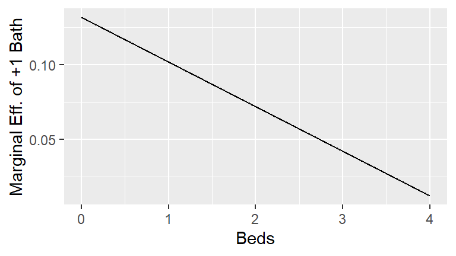

```r
beta = coef(ffit)[(grep('baths', names(coef(ffit))))]

df = tibble(x = seq(min(ahs$baths), max(ahs$baths), length = 1000),
            y = beta[1] + x*beta[2])

ggplot(df, aes(x = x, y = y)) +
  geom_line() +
  labs(y = 'Marginal Eff. of +1 Bath', x = 'Beds')
```

As we can see, the marginal effect of adding a bath is conditional on how many beds there are! The more beds we have, the less another bath adds to the house value.

Let’s perform the inference on the mean value of beds.

```r
ahs$beds %>% mean
```

```
## [1] 3.096676
```

```r
beta[1] + beta[2]*round(mean(ahs$beds))
```

```
##      baths
## 0.04206598
```

# 5 Prediction

We are going to split our sample so we can do some prediction with our fitted model. Although we should technically go through the model selection procedure again, we will assume that is the selected model on the split data.

## 5.1 Sample Splitting

This is our first step into the machine learning world. We are going to split our data into a training sample and a testing sample. The training sample is what we will use to fit the model (remember we are cheating here). The test model is where we will perform our predictions and establishing the model quality of fit in the next section.

We will start off by splitting the data so 75% is in the training model and the remainder is in the testing model.

Why 75% you may ask? Well, it is actually pretty arbitrary. Maybe in the ballpark of 75% is good for our sample size, but we could go all the way down to 50% or even a quarter if we wanted. I have seen a paper use a 1% training size, however, that had an insane amount of observations.

```r
set.seed(490) # So you can replicate at home

n = dim(ahs)[1]

# We could do this by index values
train_i = sample(1:n, n*0.75)
test_i  = setdiff(1:n, train_i)

train = ahs[train_i, ]
test  = ahs[test_i, ]

# or we can be a bit more fancy by utilizing R functions
trainers = c(1:n) %in% train_i
testers  = !trainers
```

Now we will fit the same final model on the training data and predict using the testing data.

```r
f = ffit$terms

ffitt = lm(f, ahs, subset = trainers)

yhat = predict(ffitt, ahs[testers, ]) # No fancy subset :(
```

Tada! Notice how we input the entire data set of testers, even though not every variable was used. `R` is smart enough to correctly pick the correct variables and transformations.

# 6 Quality of Fit

We will finally establish the quality of fit of this model and compare it a simpler model; we need a baseline for comparison. We are specifically interested in the smallest MSE.

```r
# MSE of final model
(  mse = sum((log(ahs[testers, value]) - yhat)^2)/sum(testers)  )
```

```
## [1] 0.8894512
```

```r
simple_fit = lm(log(value) ~ yos, ahs, subset = trainers)
simple_yhat = predict(simple_fit, ahs[testers, ])

(  mse2 = sum((log(ahs[testers, value]) - simple_yhat)^2)/sum(testers)  )
```

```
## [1] 1.311944
```

From the output we can see that our final model had less error (more accurate) than the simple model that only considers years of schooling.